# Ch6 Final Project - Testing For Treatment

## Step 1

#### Part 1

I will investigate the Cologuard test because it has a nice false-positive rate of 10%. The expected number of false positives in a group of five patients is 5 x 0.1 = 0.5

I will simulate 20 groups of 5 tests using R’s built in random number function. 1 means a false positive and 0 means no false positive.

```r
fulltable = c()
for(i in 1:20) {
  testresults = rbinom(5, 1, 0.1)
  fulltable = c(fulltable, c(i, c(testresults, sum(testresults))))
}
asmatrix <- matrix(fulltable, ncol=7, byrow=TRUE)
colnames(asmatrix) = c("Group ", " Test 1 ", " Test 2 ", " Test 3 ", " Test 4 ", " Test 5 ", " Total")
rownames(asmatrix) <- c("","","","","","","","","","","","","","","","","","","","")
as.table(asmatrix)
```

```
 Group   Test 1   Test 2   Test 3   Test 4   Test 5   Total
      1        0        0        0        0        0      0
      2        0        0        0        0        1      1
      3        0        1        0        0        0      1
      4        0        0        1        0        0      1
      5        0        0        0        0        0      0
      6        0        0        0        0        0      0
      7        0        0        1        0        1      2
      8        1        0        0        0        0      1
      9        0        1        0        1        0      2
     10        0        0        0        0        0      0
     11        0        0        0        0        0      0
     12        0        0        0        0        1      1
     13        0        0        1        0        0      1
     14        0        0        0        0        1      1
     15        0        0        0        0        0      0
     16        0        0        0        0        0      0
     17        0        0        0        0        0      0
     18        0        0        1        0        0      1
     19        0        0        0        0        0      0
     20        0        0        0        0        0      0
```

#### Part 2

From the simulated results above, I created this probability distribution:

```r
tests <- c(0, 1, 1, 1, 0, 0, 2, 1, 2, 0, 0, 1, 1, 1, 0, 0, 0, 1, 0, 0)
probabilitydistribution <- c("0", "1", "2", "3", "4", "5", 0.5, 0.4, 0.1, 0, 0, 0)
asmatrix <- matrix(probabilitydistribution, ncol=6, byrow=TRUE)
rownames(asmatrix) <- c("X", "P(X)")
colnames(asmatrix) <- c("", "", "", "", "", "")
as.table(asmatrix)
```

```
X    0   1   2   3 4 5
P(X) 0.5 0.4 0.1 0 0 0
```

```r
print(paste0("The simulated expected number of false positives(mean) is ", mean(tests)))
```

```
[1] "The simulated expected number of false positives(mean) is 0.6"
```

```r
print(paste0("The simulated variation of false positives(standard deviation) is ", sd(tests)))
```

```
[1] "The simulated variation of false positives(standard deviation) is 0.680557047378721"
```

Expected value = 0.5 x 0 + 0.4 x 1 + 0.1 x 2 + 0 x 3 + 0 x 4 + 0 x 5 = 0.6

## Step 2

To find the mean and standard deviation of X x 2100, I simply multiply the mean and standard deviation by 2100

```r
print(paste0("The simulated expected unnecessary cost(mean) is ", mean(tests)*2100))
```

```
[1] "The simulated expected unnecessary cost(mean) is 1260"
```

```r
print(paste0("The simulated variation of unnecessary costs(standard deviation) is ", sd(tests)*2100))
```

```
[1] "The simulated variation of unnecessary costs(standard deviation) is 1429.16979949531"
```

## Step 3

#### Part 1

I created this probability distribution from the binomial distribution formulas, not a simulation.

```r
x <- c("0", "1", "2", "3", "4", "5")
y <- c(0.59049, 0.32805, 0.0729, 0.0081, 0.00045, 0.00001)
probabilitydistribution <- c(x, y)
asmatrix <- matrix(probabilitydistribution, ncol=6, byrow=TRUE)
rownames(asmatrix) <- c("X", "P(X)")
colnames(asmatrix) <- c("", "", "", "", "", "")
as.table(asmatrix)
```

```
X    0       1       2      3      4       5
P(X) 0.59049 0.32805 0.0729 0.0081 0.00045 1e-05
```

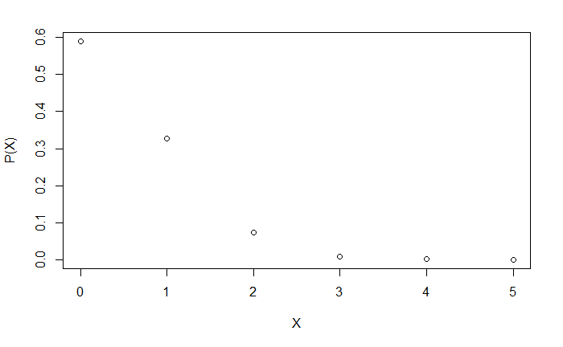

```r
plot(x, y, type="p", xlab="X", ylab="P(X)")
```

1. It is in the shape of a binomial distribution
2. The expected number of false positives in a group of 5 is 0.5. 5 x 0.1 = 0.5
3. They were quite close to each other, with the simulated value being 0.6. This is less than 1/4 standard deviations away.

#### Part 2

This probability distribution is the probability that each trial is the first false positive.

```r
x <- c("0", "1", "2", "3", "4", "5", "6", "7", "8", "9", "10")
y <- c(0.1, 0.9*0.1, 0.9^2*0.1, 0.9^3*0.1, 0.9^4*0.1, 0.9^5*0.1, 0.9^6*0.1, 0.9^7*0.1, 0.9^8*0.1, 0.9^9*0.1, 0.9^10*0.1)
probabilitydistribution <- c(x, y)
asmatrix <- matrix(probabilitydistribution, ncol=11, byrow=TRUE)
rownames(asmatrix) <- c("Y", "P(Y)")
colnames(asmatrix) <- c("", "", "", "", "", "", "", "", "", "", "")
as.table(asmatrix)
```

```
Y    0   1    2     3      4       5        6         7          8           9            10
P(Y) 0.1 0.09 0.081 0.0729 0.06561 0.059049 0.0531441 0.04782969 0.043046721 0.0387420489 0.03486784401
```

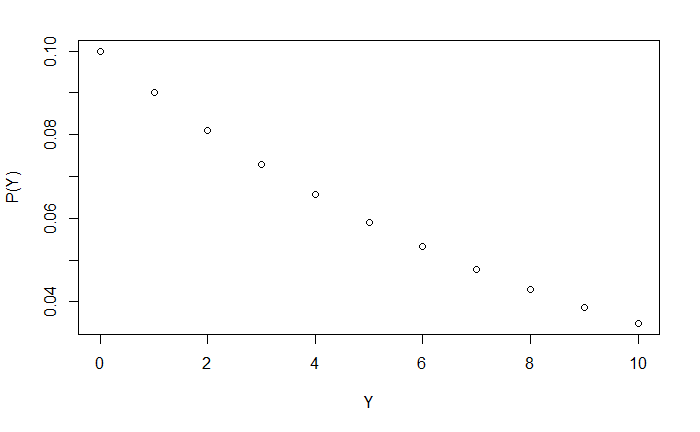

```r
plot(x, y, type="p", xlab="Y", ylab="P(Y)")
```

1. It is in the shape of a geometric distribution
2. The expected number of tests to get a false positive is 10. 1/0.1 = 10

### Conclusion

In conclusion, I recommend the Cologuard test. It only has a 10% chance of giving a false positive, thus the expected number of tests before you get a false positive is 10. Also, the predicted unnecessary cost is $210 per test ($252 according to simulations), and over 5 tests, $1050 ($1260 according to simulations). I’d say that is a reasonable price for detecting colon cancer that could otherwise be fatal.